# Imputation assignment 1

```r
library(tidyverse)
library(mice)
```

# Data frames and missing values

> Store the `nhanes` dataset from the `mice` package in a variable called `df`. Print the `df` variable.

> Output the percentage missingness for each feature as a vector.

Hint: use the `is.na()` method on the data frame.

> Show these percentages as a barplot.

> Now display the missingness pattern per age group (1, 2, 3).

Hint: use the `group_by()` function from `dplyr`.

Below you can find a visualisation of the missingness in the dataset. The grey rectangles indicate observed data, the transparent spaces indicate missing data. You will learn how to make such plots in the visualization assignments.

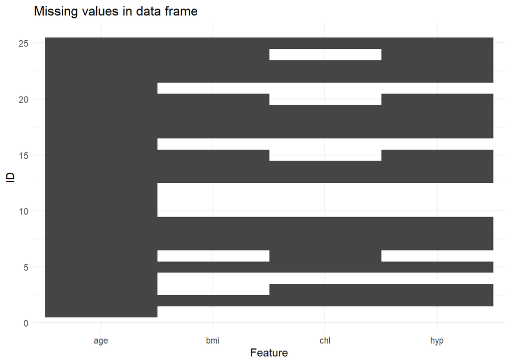

> How many rows are missing all the data except the age variable?

> Use the `md.pattern()` function from the `mice` package to display the missingness patterns.

> Using this plot, indicate:
> 1. how many rows are missing all data except the `age` feature?
> 2. how many missing values are there in the `bmi` feature?
> 3. how many rows are completely observed?
> 4. how many missing data patterns are there?

# Assignment

> Analyze the patterns of missing data for the `fdgs` dataset, and write a small paragraph on how you are going to solve the missingness in this data for an analyst who wants to compute the average weight of the population under study, assuming MAR.